# Importing publicly available data

Mark Dunning; mark ‘dot’ dunning ‘at’ cruk.cam.ac.uk, Oscar Rueda; oscar ‘dot’ rueda ‘at’ cruk.cam.ac.uk

Last modified: 20 Feb 2017

# Bioconductor data packages

The bioconductor project includes a collection of [Experimental Data](http://bioconductor.org/packages/release/BiocViews.html#___ExperimentData) packages that can be downloaded and installed in the same way as regular software packages in Bioconductor

## Example data for a package

The size limit for a new package submission is quite restrictive, so authors often have to submit example datasets separately. e.g. The [beadrrayExampleData](http://bioconductor.org/packages/release/data/experiment/html/beadarrayExampleData.html) has example data which can be used to test examples from the beadarray package

## Supplementary data for a paper

e.g. from the [Markowetz lab @ CI](http://bioconductor.org/packages/release/data/experiment/html/Fletcher2013a.html). This package not only has the data, but R scripts to reproduce the analysis in the paper.

## Curated datasets for meta-analysis

Several breast cancer datasets have been curated for use with the genefu package; which has many useful functions for classication of breast cancer

- [breastCancerNKI](http://bioconductor.org/packages/release/data/experiment/html/breastCancerNKI.html)
- [breastCancerVDX](http://bioconductor.org/packages/release/data/experiment/html/breastCancerVDX.html)

```r
source("http://www.bioconductor.org/biocLite.R")
biocLite("breastCancerNKI")
biocLite("breastCancerVDX")
```

also

- [curatedBreastData](http://bioconductor.org/packages/release/data/experiment/html/curatedBreastData.html)
- [curatedBladderData](http://bioconductor.org/packages/release/data/experiment/html/curatedBladderData.html)
- [curatedOvarianData](http://bioconductor.org/packages/release/data/experiment/html/curatedOvarianData.html)

# Data from Gene Expression Omnibus (GEO)

## Using the GEOquery package

Can search from GEO [home page](http://www.ncbi.nlm.nih.gov/geo/) or using this [Shiny app](https://zhiji.shinyapps.io/GEOsearch) to get a dataset ID which will be of the form **GSE….**.

With this identifier, we can use the [GEOquery](http://bioinformatics.oxfordjournals.org/content/23/14/1846.long) Bioconductor package

```r
library(GEOquery)
```

## Example. General procedure

Lets say we have identified a dataset which has leukemia patients. The web page describing these data is [here](http://www.ncbi.nlm.nih.gov/geo/query/acc.cgi?acc=GSE1729). The main function we need to use is `getGEO`. This downloads the *series* file for the dataset and parses the data in this file into a format that is compatible with Bioconductor.

```r
mydata <- getGEO("GSE1729")
mydata
```

sometimes datasets in GEO can include more than one platform (technology) so the result is returned in the form of a list; one item in the list for each platform. In this case, even though there is only one platform used, we have to subset the object.

```r
mydata[[1]]
```

*The recommended approach* is to download to disk first. On the [page](http://www.ncbi.nlm.nih.gov/geo/query/acc.cgi?acc=GSE1729) for the dataset you should see there is a link to the **Series Matrix File(s)**. You can copy and paste this link into R and use the `download.file` function to get data from the URL to disk. `GEOquery` is then able to read from this file in future using the filename argument. The advantage is that you don’t need an internet connection to run your script, or wait for large files to download.

```r
remotefile <- 'ftp://ftp.ncbi.nlm.nih.gov/geo/series/GSE1nnn/GSE1729/matrix/GSE1729_series_matrix.txt.gz'
destfile <- "data/GSE1729_series_matrix.txt.gz"
if(!file.exists(destfile)) download.file(remotefile, destfile)
mydata<- getGEO(filename="data/GSE1729_series_matrix.txt.gz")
```

```
File stored at:
/var/folders/b8/q7k4zz6d3x5bxrgwmst1vmmhdbgdr4/T//Rtmp0bs7S9/GPL96.soft
not all columns named in 'colClasses' exist
```

```r
mydata
```

```
ExpressionSet (storageMode: lockedEnvironment)
assayData: 22283 features, 43 samples
  element names: exprs
protocolData: none
phenoData
  sampleNames: GSM30279 GSM30280 ... GSM30321 (43 total)
  varLabels: title geo_accession ... data_row_count (26 total)
  varMetadata: labelDescription
featureData
  featureNames: 1007_s_at 1053_at ... AFFX-TrpnX-M_at (22283 total)
  fvarLabels: ID GB_ACC ... Gene Ontology Molecular Function (16 total)
  fvarMetadata: Column Description labelDescription
experimentData: use 'experimentData(object)'
Annotation: GPL96
```

The structure of the `mydata` object should be quite familiar to you. The expression values can be retrieved by the `exprs` function. Here, we just print the first 5 rows and 5 columns. In total there are 22283 rows (genes) and 43 columns (samples)

### What scale are the expression values recorded on? Is this an appropriate scale for analysis / visualisation?

```r
exprs(mydata)[1:5,1:5]
```

```
          GSM30279 GSM30280 GSM30281 GSM30282 GSM30283
1007_s_at     71.0     55.4     32.6     27.7     13.5
1053_at       89.5     59.8     50.2     67.3     63.1
117_at        41.7     24.6     40.1     21.4      8.5
121_at       369.6    265.4    264.8    164.0    156.1
1255_g_at     19.7     13.8      2.3      2.9      2.6
```

```r
summary(exprs(mydata)[,1:5])
```

```
    GSM30279          GSM30280          GSM30281         GSM30282         GSM30283
 Min.   :    0.2   Min.   :    0.1   Min.   :   0.1   Min.   :   0.1   Min.   :   0.1
 1st Qu.:   13.3   1st Qu.:    9.6   1st Qu.:   9.6   1st Qu.:   8.4   1st Qu.:   7.2
 Median :   43.3   Median :   32.2   Median :  34.4   Median :  28.2   Median :  26.0
 Mean   :  184.2   Mean   :  187.3   Mean   : 175.4   Mean   : 175.4   Mean   : 166.6
 3rd Qu.:  114.2   3rd Qu.:  100.8   3rd Qu.: 109.2   3rd Qu.: 103.0   3rd Qu.: 105.1
 Max.   :14225.6   Max.   :11934.2   Max.   :9270.5   Max.   :9905.0   Max.   :8805.2
```

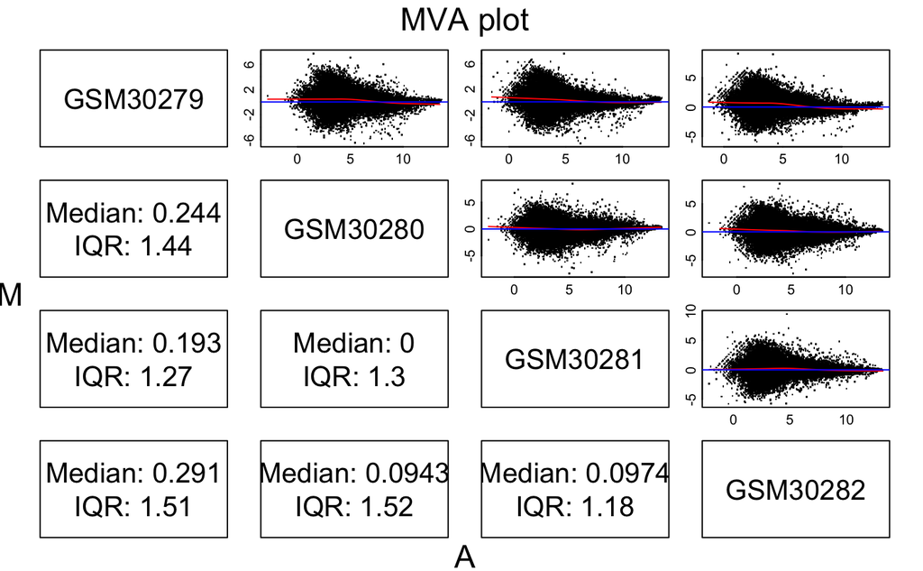

```r
mva.pairs(exprs(mydata)[,1:4],log.it = TRUE)
```

```r
pData(mydata)
```

|  | title | geo_accession | status | submission_date | last_update_date | type | channel_count | source_name_ch1 | organism_ch1 | molecule_ch1 | taxid_ch1 | description | description.1 | description.2 | platform_id | contact_name | contact_email | contact_phone | contact_department | contact_institute | contact_address | contact_city | contact_zip/postal_code | contact_country | supplementary_file | data_row_count |
| --- | --- | --- | --- | --- | --- | --- | --- | --- | --- | --- | --- | --- | --- | --- | --- | --- | --- | --- | --- | --- | --- | --- | --- | --- | --- | --- |
| GSM30279 | AML 5204 | GSM30279 | Public on Jan 26 2005 | Sep 06 2004 | May 27 2005 | RNA | 1 | Bone marrow | Homo sapiens | total RNA | 9606 | Bone marrow (BM) samples from 43 adult patients with newly de novo diagnosed AML All samples contained more than 80% blast cells. | FAB/WHO classification = M3/Acute promyelocytic leukemia (APL) with t(15;17) |  | GPL96 | Norma,Carmen,Gutierrez | normagu@usal.es | 34923291375 | Hematology | University Hospital |  | Salamanca | 37007 | Spain | ftp://ftp.ncbi.nlm.nih.gov/pub/geo/DATA/supplementary/samples/GSM30nnn/GSM30279/GSM30279.CEL.gz | 22283 |
| GSM30280 | AML 10222 | GSM30280 | Public on Jan 26 2005 | Sep 06 2004 | May 27 2005 | RNA | 1 | Bone marrow | Homo sapiens | total RNA | 9606 | Bone marrow (BM) samples from 43 adult patients with newly de novo diagnosed AML All samples contained more than 80% blast cells. | FAB/WHO classification = M3/Acute promyelocytic leukemia (APL) with t(15;17) |  | GPL96 | Norma,Carmen,Gutierrez | normagu@usal.es | 34923291375 | Hematology | University Hospital |  | Salamanca | 37007 | Spain | ftp://ftp.ncbi.nlm.nih.gov/pub/geo/DATA/supplementary/samples/GSM30nnn/GSM30280/GSM30280.CEL.gz | 22283 |
| GSM30281 | AML 12366 | GSM30281 | Public on Jan 26 2005 | Sep 06 2004 | May 27 2005 | RNA | 1 | Bone marrow | Homo sapiens | total RNA | 9606 | Bone marrow (BM) samples from 43 adult patients with newly de novo diagnosed AML All samples contained more than 80% blast cells. | FAB/WHO classification = M3/Acute promyelocytic leukemia (APL) with t(15;17) |  | GPL96 | Norma,Carmen,Gutierrez | normagu@usal.es | 34923291375 | Hematology | University Hospital |  | Salamanca | 37007 | Spain | ftp://ftp.ncbi.nlm.nih.gov/pub/geo/DATA/supplementary/samples/GSM30nnn/GSM30281/GSM30281.CEL.gz | 22283 |
| GSM30282 | AML 13058 | GSM30282 | Public on Jan 26 2005 | Sep 06 2004 | May 27 2005 | RNA | 1 | Bone marrow | Homo sapiens | total RNA | 9606 | Bone marrow (BM) samples from 43 adult patients with newly de novo diagnosed AML All samples contained more than 80% blast cells. | FAB/WHO classification = M3/Acute promyelocytic leukemia (APL) with t(15;17) |  | GPL96 | Norma,Carmen,Gutierrez | normagu@usal.es | 34923291375 | Hematology | University Hospital |  | Salamanca | 37007 | Spain | ftp://ftp.ncbi.nlm.nih.gov/pub/geo/DATA/supplementary/samples/GSM30nnn/GSM30282/GSM30282.CEL.gz | 22283 |
| GSM30283 | AML 13223 | GSM30283 | Public on Jan 26 2005 | Sep 06 2004 | May 27 2005 | RNA | 1 | Bone marrow | Homo sapiens | total RNA | 9606 | Bone marrow (BM) samples from 43 adult patients with newly de novo diagnosed AML All samples contained more than 80% blast cells. | FAB/WHO classification = M3/Acute promyelocytic leukemia (APL) with t(15;17) |  | GPL96 | Norma,Carmen,Gutierrez | normagu@usal.es | 34923291375 | Hematology | University Hospital |  | Salamanca | 37007 | Spain | ftp://ftp.ncbi.nlm.nih.gov/pub/geo/DATA/supplementary/samples/GSM30nnn/GSM30283/GSM30283.CEL.gz | 22283 |
| GSM30284 | AML 14217 | GSM30284 | Public on Jan 26 2005 | Sep 06 2004 | May 27 2005 | RNA | 1 | Bone marrow | Homo sapiens | total RNA | 9606 | Bone marrow (BM) samples from 43 adult patients with newly de novo diagnosed AML All samples contained more than 80% blast cells. | FAB/WHO classification = M3/Acute promyelocytic leukemia (APL) with t(15;17) |  | GPL96 | Norma,Carmen,Gutierrez | normagu@usal.es | 34923291375 | Hematology | University Hospital |  | Salamanca | 37007 | Spain | ftp://ftp.ncbi.nlm.nih.gov/pub/geo/DATA/supplementary/samples/GSM30nnn/GSM30284/GSM30284.CEL.gz | 22283 |
| GSM30285 | AML 14398 | GSM30285 | Public on Jan 26 2005 | Sep 06 2004 | May 27 2005 | RNA | 1 | Bone marrow | Homo sapiens | total RNA | 9606 | Bone marrow (BM) samples from 43 adult patients with newly de novo diagnosed AML All samples contained more than 80% blast cells. | FAB/WHO classification = M3/Acute promyelocytic leukemia (APL) with t(15;17) |  | GPL96 | Norma,Carmen,Gutierrez | normagu@usal.es | 34923291375 | Hematology | University Hospital |  | Salamanca | 37007 | Spain | ftp://ftp.ncbi.nlm.nih.gov/pub/geo/DATA/supplementary/samples/GSM30nnn/GSM30285/GSM30285.CEL.gz | 22283 |
| GSM30286 | AML 16089 | GSM30286 | Public on Jan 26 2005 | Sep 06 2004 | May 27 2005 | RNA | 1 | Bone marrow | Homo sapiens | total RNA | 9606 | Bone marrow (BM) samples from 43 adult patients with newly de novo diagnosed AML All samples contained more than 80% blast cells. | FAB/WHO classification = M3/Acute promyelocytic leukemia (APL) with t(15;17 |  | GPL96 | Norma,Carmen,Gutierrez | normagu@usal.es | 34923291375 | Hematology | University Hospital |  | Salamanca | 37007 | Spain | ftp://ftp.ncbi.nlm.nih.gov/pub/geo/DATA/supplementary/samples/GSM30nnn/GSM30286/GSM30286.CEL.gz | 22283 |
| GSM30287 | AML 16739 | GSM30287 | Public on Jan 26 2005 | Sep 06 2004 | May 27 2005 | RNA | 1 | Bone marrow | Homo sapiens | total RNA | 9606 | Bone marrow (BM) samples from 43 adult patients with newly de novo diagnosed AML All samples contained more than 80% blast cells. | FAB/WHO classification = M3/Acute promyelocytic leukemia (APL) with t(15;17) |  | GPL96 | Norma,Carmen,Gutierrez | normagu@usal.es | 34923291375 | Hematology | University Hospital |  | Salamanca | 37007 | Spain | ftp://ftp.ncbi.nlm.nih.gov/pub/geo/DATA/supplementary/samples/GSM30nnn/GSM30287/GSM30287.CEL.gz | 22283 |
| GSM30288 | AML 17074 | GSM30288 | Public on Jan 26 2005 | Sep 06 2004 | May 27 2005 | RNA | 1 | Bone marrow | Homo sapiens | total RNA | 9606 | Bone marrow (BM) samples from 43 adult patients with newly de novo diagnosed AML All samples contained more than 80% blast cells. | FAB/WHO classification = M3/Acute promyelocytic leukemia (APL) with t(15;17) |  | GPL96 | Norma,Carmen,Gutierrez | normagu@usal.es | 34923291375 | Hematology | University Hospital |  | Salamanca | 37007 | Spain | ftp://ftp.ncbi.nlm.nih.gov/pub/geo/DATA/supplementary/samples/GSM30nnn/GSM30288/GSM30288.CEL.gz | 22283 |

[output cut: 33 more lines]

We can visualise the expression values for a particular gene by knowing which row of the expression matrix it is found in.

## Example. Quality assessment of the downloaded data

As we have downloaded the processed and normalised data, there are limited options in terms of quality assessment. Without the *.cel* files we cannot examine the raw images or fit PLMs. The simplest form of QA is the boxplot.

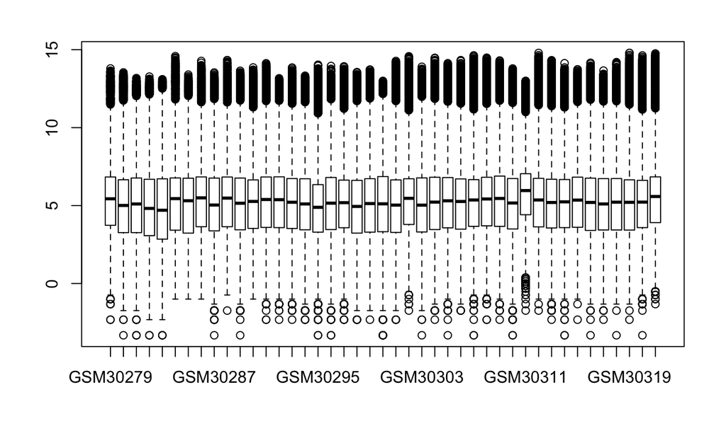

```r
boxplot(log2(exprs(mydata)))
```

What other types of QA can be applied to these data?

- Visualising the array images?
- RLE and NUSE plots?
- MA plots?
- Clustering and PCA?

The *arrayQualityMetrics* package can automatically-generate a variety of QA plots. It incorporates clustering methods that we will explore in-depth later in the course. Such methods are extremely useful for verifying known relationships between sample groups.

### (Optional) Generate an arrayQualityMetrics report for the dataset. Do any arrays seem to be poor quality?

```r
library(arrayQualityMetrics)
arrayQualityMetrics(mydata, force=TRUE)
```

The report should be generated in a folder called `arrayQualityMetrics report for mydata` (the name of the directory can be configured).

N.B the `force=TRUE` argument will make sure that the output gets written if the specified directory name already exists

An `ExpressionSet` object obeys the same subsetting rules that apply to a standard matrix or data frame in R.

- We can subset rows and columns using the square bracket notation
- Remembering that we need to specify both the row and column index separated by a `,`
  - one of these indices can be omitted if we want all rows or all columns

Here we create a subset that is just the first four arrays

- This works nicely as all the components of the object (expression values, metadata and features) all get subset

```r
subset <- mydata[,1:4]
dim(exprs(subset))
```

```
[1] 22283     4
```

```r
dim(pData(subset))
```

```
[1]  4 26
```

```r
dim(fData(subset))
```

```
[1] 22283    16
```

```r
subset <- mydata[,-c(1,4)]
subset
```

```
ExpressionSet (storageMode: lockedEnvironment)
assayData: 22283 features, 41 samples
  element names: exprs
protocolData: none
phenoData
  sampleNames: GSM30280 GSM30281 ... GSM30321 (41 total)
  varLabels: title geo_accession ... data_row_count (26 total)
  varMetadata: labelDescription
featureData
  featureNames: 1007_s_at 1053_at ... AFFX-TrpnX-M_at (22283 total)
  fvarLabels: ID GB_ACC ... Gene Ontology Molecular Function (16 total)
  fvarMetadata: Column Description labelDescription
experimentData: use 'experimentData(object)'
Annotation: GPL96
```

So in order to remove one or more poor-quality arrays we need to know their indices.

When creating a subset of an `ExpressionSet` object, we can also filter on rows. e.g. to select the first 100 genes.

```r
subset <- mydata[1:100,]
dim(subset)
```

```
Features  Samples
     100       43
```

In the next section we will look into the annotation of the dataset in more detail

## Example. Dealing with gene annotation

The annotation for the features can be retrieved by using `fData`. Because of the strict submission process, all the rows of this feature matrix are in the same order as the expression matrix; which greatly-simplifies further analysis

```r
fData(mydata)[1:5,1:5]
```

|  | ID | GB_ACC | SPOT_ID | Species Scientific Name | Annotation Date |
| --- | --- | --- | --- | --- | --- |
| 1007_s_at | 1007_s_at | U48705 | NA | Homo sapiens | Oct 6, 2014 |
| 1053_at | 1053_at | M87338 | NA | Homo sapiens | Oct 6, 2014 |
| 117_at | 117_at | X51757 | NA | Homo sapiens | Oct 6, 2014 |
| 121_at | 121_at | X69699 | NA | Homo sapiens | Oct 6, 2014 |
| 1255_g_at | 1255_g_at | L36861 | NA | Homo sapiens | Oct 6, 2014 |

```r
colnames(fData(mydata))
```

```
 [1] "ID"                               "GB_ACC"
 [3] "SPOT_ID"                          "Species Scientific Name"
 [5] "Annotation Date"                  "Sequence Type"
 [7] "Sequence Source"                  "Target Description"
 [9] "Representative Public ID"         "Gene Title"
[11] "Gene Symbol"                      "ENTREZ_GENE_ID"
[13] "RefSeq Transcript ID"             "Gene Ontology Biological Process"
[15] "Gene Ontology Cellular Component" "Gene Ontology Molecular Function"
```

```r
all(rownames(fData(mydata)) == rownames(exprs(mydata)))
```

```
[1] TRUE
```

Although this is an Affymetrix experiment, the `annotation` is set to GPL96, which is the GEO identifier for this paticular platform. All experiments in GEO run on this platform get annotated with the same table (a *SOFT* file). During the process of importing the dataset, `GEOquery` will automatically download this *SOFT* file for you.

To save some typing, we will save the features data to a new variable

```r
features <- fData(mydata)
```

Recall that a particular column from the feature matrix can be retrieved using the `$` syntax. The results will be a vector with a length corresponding to the number of genes in the experiment (in this case 22283).

```r
colnames(features)
```

## Exercise

- How many unique Entrez gene IDs are there?
  - HINT: there is a function called `unique`….
- How many features do not have an associated Entrez ID?
  - HINT: how is a probe without an Entrez ID represented in the vector?

```r
## Your answer here ##
```

## Example: Retrieving data for a particular gene

There are a number of different approaches we could use to find the rows that correspond to a particular gene

Q. Use the following code to understand the difference between `grep`, `match` and `==`

```r
features[grep("TP53", features$`Gene Symbol`),]
features[which(features$`Gene Symbol` == "TP53"),]
features[match("TP53", features$`Gene Symbol`),]
```

- `grep` will return all rows that have “TP53” *somewhere* in the gene symbol,
- `which` combined with `==` returns all rows that exactly match,
- match` returns just the first match.

You’ll probably want to use `which(features$"Gene Symbol" == TP53`)`, which in this example returns two rows.

```r
rows <- which(features$`Gene Symbol` == "TP53")
rows
```

```
[1]  1274 10723
```

The expression values relating to either of these probes can be extracted from the expression matrix (given by `exprs(mydata)`) by using the same row index. For convenience, here we save the expression matrix as a new variable and do the log$_2$ transformation.

```r
E <- log2(exprs(mydata))
E[1274,]
```

```
GSM30279 GSM30280 GSM30281 GSM30282 GSM30283 GSM30284 GSM30285 GSM30286 GSM30287 GSM30288 GSM30289
7.874059 6.883865 7.453682 7.384568 4.655352 7.738768 6.859224 7.547666 7.554589 7.180904 7.392317
GSM30290 GSM30291 GSM30292 GSM30293 GSM30294 GSM30295 GSM30296 GSM30297 GSM30298 GSM30299 GSM30300
6.361066 7.036723 7.754888 7.226894 7.975561 5.129283 6.899659 7.372430 6.536053 6.799605 7.950118
GSM30301 GSM30302 GSM30303 GSM30304 GSM30305 GSM30306 GSM30307 GSM30308 GSM30309 GSM30310 GSM30311
7.926593 6.602884 7.872829 8.481799 7.411087 7.150763 8.391888 8.185867 8.006747 7.476544 7.410239
GSM30312 GSM30313 GSM30314 GSM30315 GSM30316 GSM30317 GSM30318 GSM30319 GSM30320 GSM30321
8.008429 8.684398 8.134426 7.442943 7.656067 7.594698 8.115304 7.233620 7.774787 7.445429
```

```r
E[10723,]
```

```
GSM30279 GSM30280 GSM30281 GSM30282 GSM30283 GSM30284 GSM30285 GSM30286 GSM30287 GSM30288 GSM30289
7.522778 2.104337 5.361066 4.112700 1.321928 4.364572 2.510962 4.566815 5.916477 5.357552 5.388878
GSM30290 GSM30291 GSM30292 GSM30293 GSM30294 GSM30295 GSM30296 GSM30297 GSM30298 GSM30299 GSM30300
3.827819 5.686501 5.197708 5.708739 6.461070 1.887525 4.053111 1.137504 3.827819 6.387156 4.620586
GSM30301 GSM30302 GSM30303 GSM30304 GSM30305 GSM30306 GSM30307 GSM30308 GSM30309 GSM30310 GSM30311
6.662490 2.510962 5.205549 2.485427 3.000000 2.632268 6.345183 6.852998 4.857981 5.307429 6.133399
GSM30312 GSM30313 GSM30314 GSM30315 GSM30316 GSM30317 GSM30318 GSM30319 GSM30320 GSM30321
5.161888 6.961160 6.444601 5.070389 6.474112 4.776104 3.201634 3.137504 5.061776 4.044394
```

Having the expression values available as a vector allows us to access the plotting and statistical functions in R. If we plot either of these vectors that we extract in the previous piece of code, we plot the expression level of the probe on the $y$ axis, and the array index on the $x$ axis.

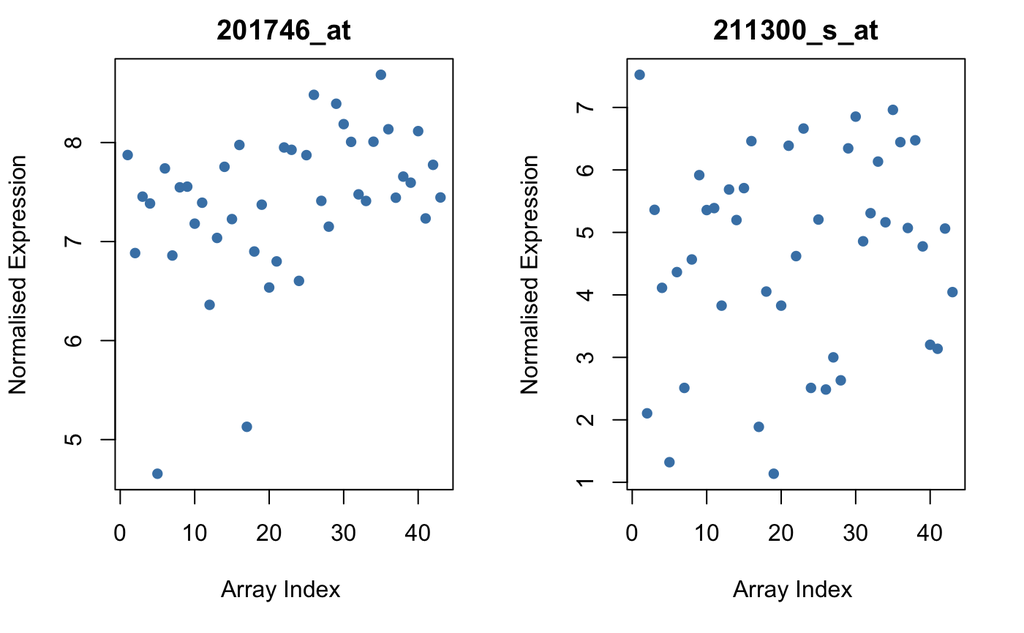

```r
par(mfrow=c(1,2))
plot(E[1274,], xlab="Array Index ",
     col="steelblue",pch=16,
     ylab="Normalised Expression",main="201746_at")
plot(E[10723,], xlab="Array Index ",
     col="steelblue",pch=16,
     ylab="Normalised Expression",main="211300_s_at")
```

Or we could plot one probe against the other

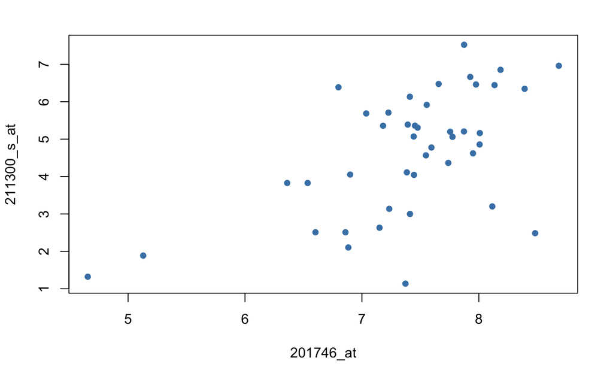

```r
par(mfrow=c(1,1))
plot(E[1274,],E[10723,],xlab="201746_at",ylab="211300_s_at",col="steelblue",pch=16)
```

```r
cor(E[1274,],E[10723,])
```

```
[1] 0.5691642
```

If we want to include information about the samples on the plot (e.g. clinical variables), then we need to look at how these data are represented in the `ExpressionSet` object. This follows in the next section.

## Which probe to use for a given Gene?

Finally, when deciding which probe to use in the analysis, we could use some of the feature information stored in the `mydata` object. For instance, one probe might represent specific transcript forms of the gene, whereas the other might be more specific.

Another approach would be to use the variability of the probe as a measure of how *informative* it is in the study. The `IQR` (`?IQR`) function can compute this.

```r
IQR(E[1274,])
```

```
[1] 0.7344926
```

```r
IQR(E[10723,])
```

```
[1] 2.297881
```

As we will see later, the `genefilter` package in Bioconductor provides several methods to assist in the filtering of microarray data based on a lack of annotation or low variation.

# GEO Example. Dealing with large cohorts with clinical data

For this second example, we will import a patient cohort

```r
remotefile <- 'ftp://ftp.ncbi.nlm.nih.gov/geo/series/GSE18nnn/GSE18088/matrix/GSE18088_series_matrix.txt.gz'
destfile <- "data/GSE18088_series_matrix.txt.gz"
if(!file.exists(destfile)) download.file(remotefile, destfile)
cohort <- getGEO(filename="data/GSE18088_series_matrix.txt.gz")
```

```
File stored at:
/var/folders/b8/q7k4zz6d3x5bxrgwmst1vmmhdbgdr4/T//Rtmp0bs7S9/GPL570.soft
not all columns named in 'colClasses' exist
```

```r
cohort
```

```
ExpressionSet (storageMode: lockedEnvironment)
assayData: 54675 features, 53 samples
  element names: exprs
protocolData: none
phenoData
  sampleNames: GSM452148 GSM452149 ... GSM452200 (53 total)
  varLabels: title geo_accession ... data_row_count (36 total)
  varMetadata: labelDescription
featureData
  featureNames: 1007_s_at 1053_at ... AFFX-TrpnX-M_at (54675 total)
  fvarLabels: ID GB_ACC ... Gene Ontology Molecular Function (16 total)
  fvarMetadata: Column Description labelDescription
experimentData: use 'experimentData(object)'
Annotation: GPL570
```

As before, we can query the expression matrix and features

```r
head(exprs(cohort)[,1:5])
```

```
          GSM452148 GSM452149 GSM452150 GSM452151 GSM452152
1007_s_at  7.558720  9.126071  8.734507  8.258174  8.481975
1053_at    6.750651  6.601878  6.923114  6.938496  7.165163
117_at     5.717422  5.605266  5.015487  5.194663  5.120472
121_at     6.437157  6.434629  6.392033  6.625201  6.412066
1255_g_at  4.078927  3.713068  3.794983  3.681261  3.858806
1294_at    6.315349  6.306886  6.049185  6.765942  6.234213
```

```r
head(fData(cohort)[,1:5])
```

|  | ID | GB_ACC | SPOT_ID | Species Scientific Name | Annotation Date |
| --- | --- | --- | --- | --- | --- |
| 1007_s_at | 1007_s_at | U48705 | NA | Homo sapiens | Oct 6, 2014 |
| 1053_at | 1053_at | M87338 | NA | Homo sapiens | Oct 6, 2014 |
| 117_at | 117_at | X51757 | NA | Homo sapiens | Oct 6, 2014 |
| 121_at | 121_at | X69699 | NA | Homo sapiens | Oct 6, 2014 |
| 1255_g_at | 1255_g_at | L36861 | NA | Homo sapiens | Oct 6, 2014 |
| 1294_at | 1294_at | L13852 | NA | Homo sapiens | Oct 6, 2014 |

And as always, check the distribution of the samples

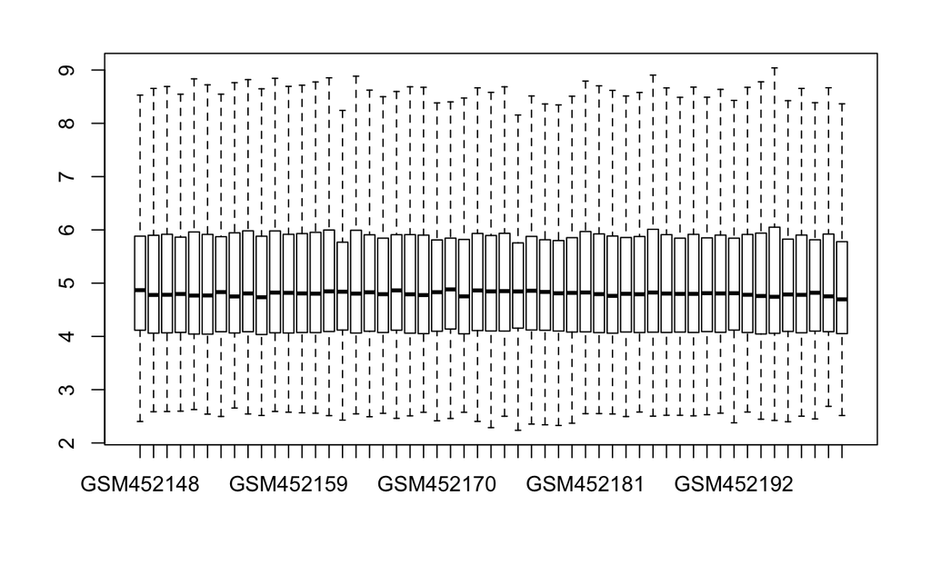

```r
boxplot(exprs(cohort),outline=FALSE)
```

An extra feature of this dataset is the availability of clinical information

```r
pData(cohort)[1:5,1:5]
```

|  | title | geo_accession | status | submission_date | last_update_date |
| --- | --- | --- | --- | --- | --- |
| GSM452148 | C1 | GSM452148 | Public on Apr 10 2011 | Sep 11 2009 | Apr 10 2011 |
| GSM452149 | C2 | GSM452149 | Public on Apr 10 2011 | Sep 11 2009 | Apr 10 2011 |
| GSM452150 | C3 | GSM452150 | Public on Apr 10 2011 | Sep 11 2009 | Apr 10 2011 |
| GSM452151 | C6 | GSM452151 | Public on Apr 10 2011 | Sep 11 2009 | Apr 10 2011 |
| GSM452152 | C7 | GSM452152 | Public on Apr 10 2011 | Sep 11 2009 | Apr 10 2011 |

```r
colnames(pData(cohort))
```

```
 [1] "title"                   "geo_accession"           "status"
 [4] "submission_date"         "last_update_date"        "type"
 [7] "channel_count"           "source_name_ch1"         "organism_ch1"
[10] "characteristics_ch1"     "characteristics_ch1.1"   "characteristics_ch1.2"
[13] "characteristics_ch1.3"   "characteristics_ch1.4"   "characteristics_ch1.5"
[16] "characteristics_ch1.6"   "molecule_ch1"            "extract_protocol_ch1"
[19] "label_ch1"               "label_protocol_ch1"      "taxid_ch1"
[22] "hyb_protocol"            "scan_protocol"           "description"
[25] "data_processing"         "platform_id"             "contact_name"
[28] "contact_email"           "contact_department"      "contact_institute"
[31] "contact_address"         "contact_city"            "contact_zip/postal_code"
[34] "contact_country"         "supplementary_file"      "data_row_count"
```

As we did with the gene annotation in the previous example, we can save the metadata as an object to save some typing.

```r
pd <- pData(cohort)
View(pd)
colnames(pd)
```

```
 [1] "title"                   "geo_accession"           "status"
 [4] "submission_date"         "last_update_date"        "type"
 [7] "channel_count"           "source_name_ch1"         "organism_ch1"
[10] "characteristics_ch1"     "characteristics_ch1.1"   "characteristics_ch1.2"
[13] "characteristics_ch1.3"   "characteristics_ch1.4"   "characteristics_ch1.5"
[16] "characteristics_ch1.6"   "molecule_ch1"            "extract_protocol_ch1"
[19] "label_ch1"               "label_protocol_ch1"      "taxid_ch1"
[22] "hyb_protocol"            "scan_protocol"           "description"
[25] "data_processing"         "platform_id"             "contact_name"
[28] "contact_email"           "contact_department"      "contact_institute"
[31] "contact_address"         "contact_city"            "contact_zip/postal_code"
[34] "contact_country"         "supplementary_file"      "data_row_count"
```

The interesting columns tend to be in columns starting “characteristics_”

```r
pd[1:4,10:16]
```

|  | characteristics_ch1 | characteristics_ch1.1 | characteristics_ch1.2 | characteristics_ch1.3 | characteristics_ch1.4 | characteristics_ch1.5 | characteristics_ch1.6 |
| --- | --- | --- | --- | --- | --- | --- | --- |
| GSM452148 | localization: proximal | gender: male | relapse: no | microsatellite status: MSI-high | age at diagnosis, years: 61 | grading: G2 | pt: 3 |
| GSM452149 | localization: distal | gender: female | relapse: no | microsatellite status: MSS | age at diagnosis, years: 65 | grading: G3 | pt: 3 |
| GSM452150 | localization: distal | gender: female | relapse: no | microsatellite status: MSS | age at diagnosis, years: 56 | grading: G3 | pt: 3 |
| GSM452151 | localization: proximal | gender: male | relapse: no | microsatellite status: MSS | age at diagnosis, years: 56 | grading: G2 | pt: 3 |

Exercise:

- How many males and females are there in the study?
- How many of the patients relapsed?

```r
## Your answer here ##
```

## Incorporating metadata into the analysis

This cateogorical information can be used in our analysis.

Lets take the gene *XIST* and find what probes target this gene;

```r
rows <- which(fData(cohort)$"Gene Symbol" == "XIST")
rows
```

```
[1] 23518 31009 33848 33849 33850 36926 52962
```

The vector that we have just created,`rows`, can be used to subset the expression matrix. If we plot the expression values corresponding to the first probe, it clearly exhibits bi-modal behaviour.

```r
subset <- exprs(cohort)[rows,]
dim(subset)
```

```
[1]  7 53
```

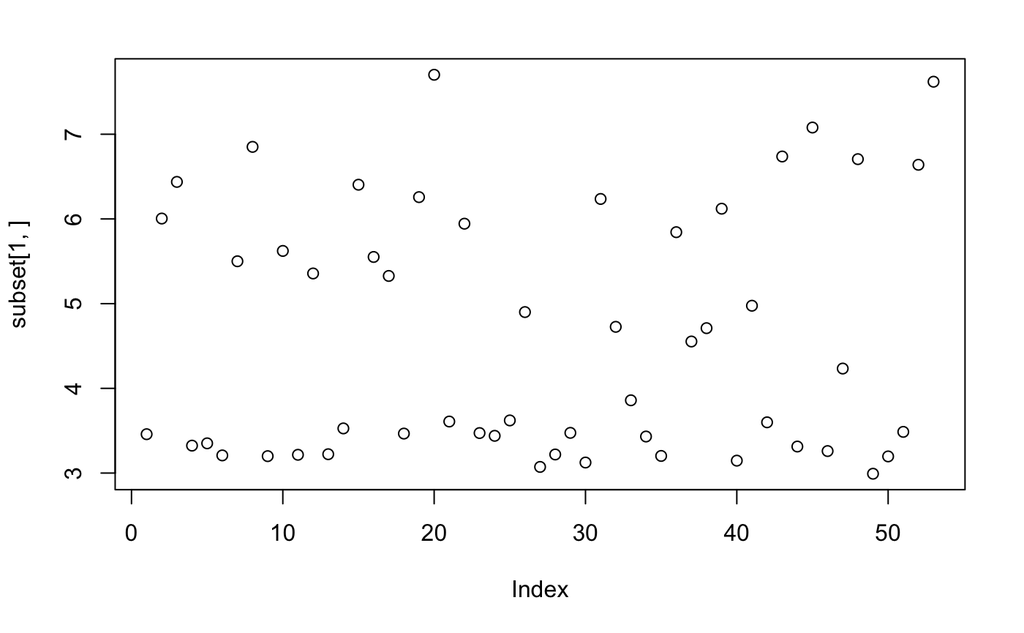

```r
plot(subset[1,])
```

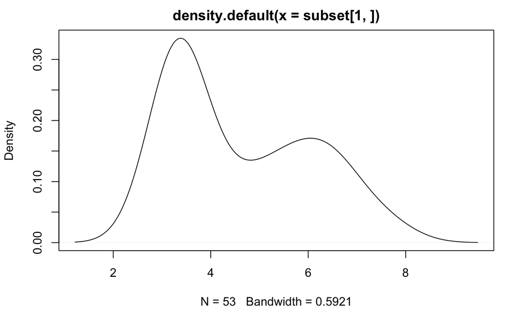

```r
plot(density(subset[1,]))
```

Up to this point, we have been using the `boxplot` function to visualise the distribution of a matrix of expression values. In fact, the `boxplot` function is versatile and can accept different types of data as input.

A common way of creating a `boxplot` is using the *formula* syntax in R. Also used in statistics (and linear modelling in particular) we can specify a *response* and predictor variable. In the case of our analysis, we are looking to see if the gene expression level of a particular gene can be explained by a categorical variable (e.g. gender).

Exercise:

- Produce a boxplot to see if the first probe that targets XIST shows and different between males and females
  - the expression values for the first probe can be found in `subset[1,]`

```r
## Your answer here ##
```

- Note that the order of categories on the boxplot is determined by alphabetical order
  - for how to change this, see the note in the Appendix below

The boxplot provides a nice visualisation of the difference between the groups of interest. For a quick-and-dirty assessment of whether this difference is statistically signficant we could use the standard `t.test` function.

- However, as we will see in subsequent sections, more sophisticated approaches are required.

```r
t.test(subset[1,]~gender)
```

# Summary

If we wanted to query a particular gene in our dataset and know if it exhibits a difference between a biological condition of interest

# Appendix

## Example: Extra manipulation of the clinical data

Q. What is the age distribution of the samples?

This is trickier without extra manipulation of the data. R supports various string-cleaning operations such as substituting text, trimming etc. A commonly-used function is `gsub` (`?gsub`) which replaces a given *pattern* with a *replacement* string for every element in a character vector. In this case, we want to replace `age at diagnosis, years:` with the blank string `""`. The R code is thus;

```r
clinvars <- pd[,10:16]
gsub("age at diagnosis, years: ","",clinvars$characteristics_ch1.4)
```

However, R still treats the result as a character vector (as each item has `""` around it). We need to explicitly convert to numeric values before proceeding

```r
clinvars$characteristics_ch1.4 <- as.numeric(gsub("age at diagnosis, years: ","",clinvars$characteristics_ch1.4))
hist(clinvars$characteristics_ch1.4)
```

Q. Clean-up the gender column so that the values are either `male` or `female`.

```r
nchar(as.character(clinvars$characteristics_ch1.1))
sex <- substr(clinvars$characteristics_ch1.1,9,nchar(as.character(clinvars$characteristics_ch1.1)))
sex
```

## Changing the plotting order in a boxplot

```r
gender <- pd$characteristics_ch1.1
gender <- factor(gender, levels = c("gender: male", "gender: female"))
gender
boxplot(subset[1,]~gender)
```

## Supplementary data from GEO

Example from the Bioconductor course in [Montevideo, Uruguay](http://bioconductor.org/help/course-materials/2015/Uruguay2015/)

We can also download supplementary files from GEO. In the case of Affymetrix arrays, this may include the *.CEL* files

```r
x = getGEOSuppFiles("GSE20986")
x
```

The supplementary file comes as a *tar* archive, which we need to extract to get the individual cel files.

```r
untar("GSE20986/GSE20986_RAW.tar", exdir = "suppdata")
list.files("suppdata/")
```

Each cel file is zipped, so we unzip with *gunzip*.

```r
cels = list.files("suppdata/", pattern = "[gz]")
sapply(paste("suppdata", cels, sep = "/"), gunzip)
```

We can now proceed as with the Affymetrix workflow.

```r
library(affy)
raw <- ReadAffy(celfile.path = "suppdata/")
raw
boxplot(raw)
```

## Data in ArrayExpress

The ArrayExpress vignette has various examples of importing data from the *ArrayExpress* repository into R. Similar to `getGEO` from `GEOquery`, the `getAE` function can do the import if the accession number is known. If we want just normalised data, we set an argument `type=processed`.

```r
library(ArrayExpress)
aeData <- getAE("E-GEOD-69017",type="processed")
aeData
```

Alternatively, we can get the full dataset (including raw cel files) with `type=full`.

```r
rawdata <- getAE("E-GEOD-69017",type="full")
```

We can process the *cel* files using the Affymetrix workflow, or `ArrayExpress` can process them for us.

```r
procdata <- ae2bioc(rawdata)
```